# Initial data analysis with nflverse packages

```r
library(tidyverse)
library(nflverse)
library(gt)
```

```r
player_stats <- nflreadr::load_player_stats(seasons = most_recent_season(),
                                            stat_type = "offense")
```

`nflreadr::load_player_stats()`. Arguments include:

- `seasons=`: numeric vector, or use the `most_recent_season()` function
- `stat_type=`: takes “offense”, “defense”, or “kicking”
- `file_type=`: takes “rds” (default), “qs”, “csv”, or “parquet”

From the book:

> As an example, let’s say you need to get Patrick Mahomes’ total passing yard and attempts from the 2022 season. You could do so via load_pbp() but, if you do not need further context (such as down, distance, quarter, etc.), using load_player_stats() is much more efficient.

```r
player_stats %>% names()
```

```
 [1] "player_id"                   "player_name"                 "player_display_name"         "position"                    "position_group"
 [6] "headshot_url"                "recent_team"                 "season"                      "week"                        "season_type"
[11] "opponent_team"               "completions"                 "attempts"                    "passing_yards"               "passing_tds"
[16] "interceptions"               "sacks"                       "sack_yards"                  "sack_fumbles"                "sack_fumbles_lost"
[21] "passing_air_yards"           "passing_yards_after_catch"   "passing_first_downs"         "passing_epa"                 "passing_2pt_conversions"
[26] "pacr"                        "dakota"                      "carries"                     "rushing_yards"               "rushing_tds"
[31] "rushing_fumbles"             "rushing_fumbles_lost"        "rushing_first_downs"         "rushing_epa"                 "rushing_2pt_conversions"
[36] "receptions"                  "targets"                     "receiving_yards"             "receiving_tds"               "receiving_fumbles"
[41] "receiving_fumbles_lost"      "receiving_air_yards"         "receiving_yards_after_catch" "receiving_first_downs"       "receiving_epa"
[46] "receiving_2pt_conversions"   "racr"                        "target_share"                "air_yards_share"             "wopr"
[51] "special_teams_tds"           "fantasy_points"              "fantasy_points_ppr"
```

```r
(receiving_stats <- player_stats %>%
  filter(position %in% c('WR', 'RB', 'TE')) %>%
  rename(receiving_receptions = receptions,
         receiving_targets = targets,
         receiving_racr = racr,
         receiving_air_yards_share = air_yards_share,
         receiving_target_share = target_share,
         receiving_wopr = wopr) %>%
  select(recent_team, player_display_name, position, fantasy_points, starts_with("receiving")) %>%
  group_by(recent_team, player_display_name, position) %>%
  # summarize(across(starts_with("receiving"), mean, na.rm = TRUE))
  summarise(
    sum_fantasy_points = sum(fantasy_points, na.rm = TRUE),
    mean_fantasy_points = mean(fantasy_points, na.rm = TRUE),
    across(
      starts_with("receiving"),
      list(
        mean = ~round(mean(., na.rm = TRUE), 2),
        sum = ~round(sum(., na.rm = TRUE), 2)
      ),
      .names = "{.fn}_{.col}"
    ),
    fantasy_points_per_wopr = sum_fantasy_points / sum_receiving_wopr,
    games_played = n(),
    .groups='drop'
  ) %>%
  # ungroup() %>%
  arrange(-sum_receiving_targets) %>%
  filter(sum_receiving_targets >= 5))
```

| recent_team | player_display_name | position | sum_fantasy_points | mean_fantasy_points | mean_receiving_receptions | sum_receiving_receptions | mean_receiving_targets | sum_receiving_targets | mean_receiving_yards | sum_receiving_yards | mean_receiving_tds | sum_receiving_tds | mean_receiving_fumbles | sum_receiving_fumbles | mean_receiving_fumbles_lost | sum_receiving_fumbles_lost | mean_receiving_air_yards | sum_receiving_air_yards | mean_receiving_yards_after_catch | sum_receiving_yards_after_catch | mean_receiving_first_downs | sum_receiving_first_downs | mean_receiving_epa | sum_receiving_epa | mean_receiving_2pt_conversions | sum_receiving_2pt_conversions | mean_receiving_racr | sum_receiving_racr | mean_receiving_target_share | … |
| --- | --- | --- | --- | --- | --- | --- | --- | --- | --- | --- | --- | --- | --- | --- | --- | --- | --- | --- | --- | --- | --- | --- | --- | --- | --- | --- | --- | --- | --- | --- |
| NYJ | Garrett Wilson | WR | 39.70 | 7.9400000 | 6.60 | 33 | 11.20 | 56 | 58.40 | 292 | 0.40 | 2 | 0.20 | 1 | 0.20 | 1 | 90.40 | 452 | 24.40 | 122 | 3.60 | 18 | -1.48 | -7.41 | 0.0 | 0 | 0.69 | 3.44 | 0.30 | … |
| SEA | DK Metcalf | WR | 54.90 | 9.1500000 | 5.17 | 31 | 9.00 | 54 | 78.17 | 469 | 0.33 | 2 | 0.33 | 2 | 0.33 | 2 | 112.00 | 672 | 30.67 | 184 | 2.67 | 16 | -0.31 | -1.86 | 0.0 | 0 | 0.73 | 4.36 | 0.22 | … |
| NYG | Malik Nabers | WR | 56.60 | 14.1500000 | 8.75 | 35 | 13.00 | 52 | 96.50 | 386 | 0.75 | 3 | 0.00 | 0 | 0.00 | 0 | 135.00 | 540 | 39.00 | 156 | 4.75 | 19 | 6.15 | 24.62 | 0.0 | 0 | 0.83 | 3.31 | 0.40 | … |
| SEA | Jaxon Smith-Njigba | WR | 37.00 | 6.1666667 | 5.67 | 34 | 8.17 | 49 | 51.67 | 310 | 0.17 | 1 | 0.17 | 1 | 0.00 | 0 | 60.83 | 365 | 24.33 | 146 | 2.83 | 17 | 2.41 | 14.48 | 0.0 | 0 | 1.79 | 10.77 | 0.19 | … |
| CLE | Amari Cooper | WR | 32.80 | 6.5600000 | 4.00 | 20 | 9.40 | 47 | 41.60 | 208 | 0.40 | 2 | 0.00 | 0 | 0.00 | 0 | 130.60 | 653 | 8.40 | 42 | 2.00 | 10 | -1.23 | -6.15 | 0.0 | 0 | 0.32 | 1.60 | 0.28 | … |
| NYG | Wan'Dale Robinson | WR | 36.80 | 7.3600000 | 6.40 | 32 | 9.40 | 47 | 46.00 | 230 | 0.40 | 2 | 0.00 | 0 | 0.00 | 0 | 43.00 | 215 | 23.60 | 118 | 2.60 | 13 | -2.49 | -12.45 | 0.0 | 0 | 1.32 | 6.58 | 0.27 | … |
| CAR | Diontae Johnson | WR | 38.80 | 7.7600000 | 4.60 | 23 | 9.00 | 45 | 52.40 | 262 | 0.40 | 2 | 0.00 | 0 | 0.00 | 0 | 87.40 | 437 | 15.80 | 79 | 2.80 | 14 | -1.24 | -6.19 | 0.0 | 0 | 0.53 | 2.63 | 0.26 | … |
| HOU | Nico Collins | WR | 74.70 | 14.9400000 | 6.40 | 32 | 9.00 | 45 | 113.40 | 567 | 0.60 | 3 | 0.00 | 0 | 0.00 | 0 | 108.00 | 540 | 39.00 | 195 | 5.40 | 27 | 6.02 | 30.12 | 0.0 | 0 | 1.09 | 5.43 | 0.25 | … |
| ATL | Drake London | WR | 53.40 | 10.6800000 | 6.40 | 32 | 8.80 | 44 | 70.80 | 354 | 0.60 | 3 | 0.00 | 0 | 0.00 | 0 | 87.80 | 439 | 20.00 | 100 | 3.60 | 18 | 3.24 | 16.18 | 0.0 | 0 | 0.84 | 4.19 | 0.26 | … |
| MIN | Justin Jefferson | WR | 69.00 | 13.8000000 | 5.20 | 26 | 8.60 | 43 | 90.00 | 450 | 0.80 | 4 | 0.20 | 1 | 0.00 | 0 | 114.20 | 571 | 26.80 | 134 | 3.60 | 18 | 5.07 | 25.36 | 0.0 | 0 | 0.88 | 4.40 | 0.33 | … |

[output cut: 249 more lines]

```r
receiving_stats %>%
  group_by(recent_team) %>%
  slice_max(sum_receiving_wopr) %>%
  arrange(-sum_receiving_wopr)
```

| recent_team | player_display_name | position | sum_fantasy_points | mean_fantasy_points | mean_receiving_receptions | sum_receiving_receptions | mean_receiving_targets | sum_receiving_targets | mean_receiving_yards | sum_receiving_yards | mean_receiving_tds | sum_receiving_tds | mean_receiving_fumbles | sum_receiving_fumbles | mean_receiving_fumbles_lost | sum_receiving_fumbles_lost | mean_receiving_air_yards | sum_receiving_air_yards | mean_receiving_yards_after_catch | sum_receiving_yards_after_catch | mean_receiving_first_downs | sum_receiving_first_downs | mean_receiving_epa | sum_receiving_epa | mean_receiving_2pt_conversions | sum_receiving_2pt_conversions | mean_receiving_racr | sum_receiving_racr | mean_receiving_target_share | … |
| --- | --- | --- | --- | --- | --- | --- | --- | --- | --- | --- | --- | --- | --- | --- | --- | --- | --- | --- | --- | --- | --- | --- | --- | --- | --- | --- | --- | --- | --- | --- |
| MIN | Justin Jefferson | WR | 69.00 | 13.800000 | 5.20 | 26 | 8.60 | 43 | 90.00 | 450 | 0.80 | 4 | 0.20 | 1 | 0.00 | 0 | 114.20 | 571 | 26.80 | 134 | 3.60 | 18 | 5.07 | 25.36 | 0.0 | 0 | 0.88 | 4.40 | 0.33 | … |
| CLE | Amari Cooper | WR | 32.80 | 6.560000 | 4.00 | 20 | 9.40 | 47 | 41.60 | 208 | 0.40 | 2 | 0.00 | 0 | 0.00 | 0 | 130.60 | 653 | 8.40 | 42 | 2.00 | 10 | -1.23 | -6.15 | 0.0 | 0 | 0.32 | 1.60 | 0.28 | … |
| WAS | Terry McLaurin | WR | 40.50 | 8.100000 | 4.60 | 23 | 7.20 | 36 | 60.60 | 303 | 0.40 | 2 | 0.00 | 0 | 0.00 | 0 | 106.60 | 533 | 14.20 | 71 | 2.80 | 14 | 2.52 | 12.59 | 0.0 | 0 | 0.55 | 2.76 | 0.27 | … |
| NYG | Malik Nabers | WR | 56.60 | 14.150000 | 8.75 | 35 | 13.00 | 52 | 96.50 | 386 | 0.75 | 3 | 0.00 | 0 | 0.00 | 0 | 135.00 | 540 | 39.00 | 156 | 4.75 | 19 | 6.15 | 24.62 | 0.0 | 0 | 0.83 | 3.31 | 0.40 | … |
| PIT | George Pickens | WR | 28.00 | 5.600000 | 4.60 | 23 | 7.20 | 36 | 62.00 | 310 | 0.00 | 0 | 0.20 | 1 | 0.20 | 1 | 84.40 | 422 | 11.80 | 59 | 2.60 | 13 | 2.07 | 10.35 | 0.0 | 0 | 0.70 | 3.50 | 0.28 | … |
| NO | Rashid Shaheed | WR | 54.50 | 10.900000 | 3.80 | 19 | 6.80 | 34 | 67.60 | 338 | 0.60 | 3 | 0.00 | 0 | 0.00 | 0 | 114.00 | 570 | 19.40 | 97 | 2.20 | 11 | 1.18 | 5.89 | 0.0 | 0 | 0.71 | 3.57 | 0.26 | … |
| SEA | DK Metcalf | WR | 54.90 | 9.150000 | 5.17 | 31 | 9.00 | 54 | 78.17 | 469 | 0.33 | 2 | 0.33 | 2 | 0.33 | 2 | 112.00 | 672 | 30.67 | 184 | 2.67 | 16 | -0.31 | -1.86 | 0.0 | 0 | 0.73 | 4.36 | 0.22 | … |
| DEN | Courtland Sutton | WR | 28.40 | 5.680000 | 3.40 | 17 | 8.20 | 41 | 44.80 | 224 | 0.20 | 1 | 0.00 | 0 | 0.00 | 0 | 109.80 | 549 | 6.80 | 34 | 2.60 | 13 | -1.70 | -8.51 | 0.0 | 0 | 0.45 | 2.25 | 0.26 | … |
| NYJ | Garrett Wilson | WR | 39.70 | 7.940000 | 6.60 | 33 | 11.20 | 56 | 58.40 | 292 | 0.40 | 2 | 0.20 | 1 | 0.20 | 1 | 90.40 | 452 | 24.40 | 122 | 3.60 | 18 | -1.48 | -7.41 | 0.0 | 0 | 0.69 | 3.44 | 0.30 | … |
| MIA | Tyreek Hill | WR | 37.70 | 7.540000 | 4.60 | 23 | 7.80 | 39 | 57.20 | 286 | 0.20 | 1 | 0.00 | 0 | 0.00 | 0 | 92.40 | 462 | 28.00 | 140 | 2.40 | 12 | 0.07 | 0.35 | 0.0 | 0 | 0.69 | 3.44 | 0.26 | … |

[output cut: 22 more lines]

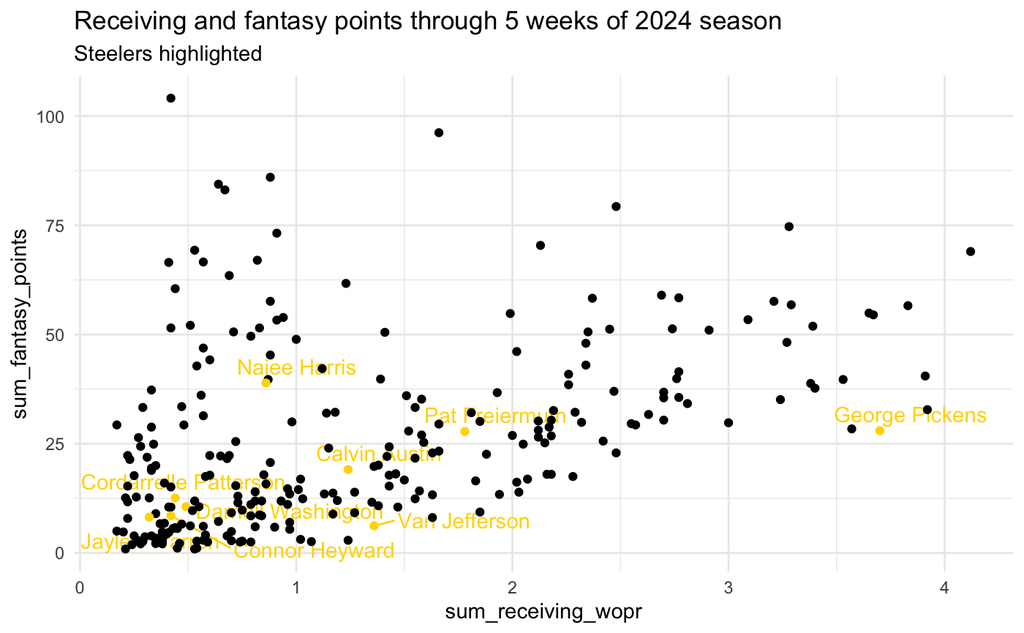

```r
receiving_stats %>%
  ggplot(.,
         aes(x=sum_receiving_wopr,
             y=sum_fantasy_points,
             color=if_else(recent_team == 'PIT', 'PIT', 'Other'))) +
  ggrepel::geom_text_repel(data = . %>% filter(recent_team == 'PIT'),
                           aes(label = player_display_name)) +
  geom_point() +
  ggtitle('Receiving and fantasy points through 5 weeks of 2024 season',
          subtitle = 'Steelers highlighted') +
  scale_color_manual(values = c('Other' = 'black',
                                'PIT' = 'gold')) +
  theme_minimal() +
  theme(legend.position = 'none')
```

```r
roster_2024 <- nflreadr::load_rosters(2024) %>%
  select(full_name, gsis_id, headshot_url)
```

Some of these statistics won’t have any meaning summed (or possibly by taking an average), so I’ll dig into each one to get clearer on that.

# Adjusted net yards per passing attempt

A note from the book on play-by-play passing stats:

> Aside from when attempting to replicate the official statistics, it is better to use just passer as it removes those instances where a QB spike, scramble, or sack my skew the results of your data.

```r
player_stats %>%
  # add opponent_team to the group_by() for game-by-game stats
  group_by(recent_team, player_name) %>%
  # this is copied from the book, which replicates the passing tables found in Pro Football Reference
  # the AY / A stat is the one that I'm most interested in
  summarize(
    completions = sum(completions),
    attempts = sum(attempts),
    cmp_pct = completions / attempts,
    yards = sum(passing_yards),
    touchdowns = sum(passing_tds),
    td_pct = touchdowns / attempts * 100,
    interceptions = sum(interceptions),
    int_pct = interceptions / attempts * 100,
    first_down = sum(passing_first_downs),
    yards_attempt = yards / attempts,
    adj_yards_attempt = (yards + 20 * touchdowns - 45 * interceptions) / attempts,
    yards_completions = yards / completions,
    yards_game = yards / 17,
    sacks = sum(sacks),
    sack_yards = sum(sack_yards),
    sack_pct = sacks / (attempts + sacks) * 100,
    .groups = 'drop') %>%
  filter(attempts > 100) %>%
  select(recent_team, player_name, adj_yards_attempt, everything()) %>%
  # arrange(-adj_yards_attempt)
  arrange(-sack_yards)
```

| recent_team | player_name | adj_yards_attempt | completions | attempts | cmp_pct | yards | touchdowns | td_pct | interceptions | int_pct | first_down | yards_attempt | yards_completions | yards_game | sacks | sack_yards | sack_pct |
| --- | --- | --- | --- | --- | --- | --- | --- | --- | --- | --- | --- | --- | --- | --- | --- | --- | --- |
| CLE | D.Watson | 4.642045 | 106 | 176 | 0.6022727 | 852 | 5 | 2.840909 | 3 | 1.7045455 | 37 | 4.840909 | 8.037736 | 50.11765 | 26 | 154 | 12.871287 |
| CHI | C.Williams | 5.947059 | 107 | 170 | 0.6294118 | 1091 | 5 | 2.941176 | 4 | 2.3529412 | 49 | 6.417647 | 10.196262 | 64.17647 | 17 | 132 | 9.090909 |
| SEA | G.Smith | 6.486056 | 173 | 251 | 0.6892430 | 1778 | 6 | 2.390438 | 6 | 2.3904382 | 89 | 7.083665 | 10.277457 | 104.58824 | 19 | 118 | 7.037037 |
| HOU | C.Stroud | 7.853107 | 122 | 177 | 0.6892655 | 1385 | 7 | 3.954802 | 3 | 1.6949153 | 68 | 7.824859 | 11.352459 | 81.47059 | 14 | 108 | 7.329843 |
| NE | J.Brissett | 5.118519 | 79 | 135 | 0.5851852 | 696 | 2 | 1.481481 | 1 | 0.7407407 | 35 | 5.155556 | 8.810127 | 40.94118 | 17 | 108 | 11.184211 |
| LV | G.Minshew | 6.207143 | 99 | 140 | 0.7071429 | 1014 | 4 | 2.857143 | 5 | 3.5714286 | 50 | 7.242857 | 10.242424 | 59.64706 | 15 | 106 | 9.677419 |
| LA | M.Stafford | 6.645714 | 118 | 175 | 0.6742857 | 1238 | 3 | 1.714286 | 3 | 1.7142857 | 54 | 7.074286 | 10.491525 | 72.82353 | 16 | 105 | 8.376963 |
| TB | B.Mayfield | 8.457516 | 110 | 153 | 0.7189542 | 1164 | 11 | 7.189542 | 2 | 1.3071895 | 65 | 7.607843 | 10.581818 | 68.47059 | 16 | 99 | 9.467456 |
| NYJ | A.Rodgers | 5.785714 | 111 | 182 | 0.6098901 | 1093 | 7 | 3.846154 | 4 | 2.1978022 | 56 | 6.005495 | 9.846847 | 64.29412 | 13 | 98 | 6.666667 |
| JAX | T.Lawrence | 7.243590 | 93 | 156 | 0.5961538 | 1100 | 6 | 3.846154 | 2 | 1.2820513 | 50 | 7.051282 | 11.827957 | 64.70588 | 12 | 97 | 7.142857 |

[output cut: 18 more lines]

# Play by play data

```r
play_by_play_2024 <- load_pbp(seasons=most_recent_season())
```

```r
play_by_play_2024 %>%
  filter(posteam == 'PIT',
         down == 1,
         play_type %in% c('run', 'pass')) %>%
  group_by(posteam, defteam) %>%
  # group_by(posteam, defteam, play_type) %>%
  # tally()
  summarise(avg_yards_gained = mean(yards_gained),
            .groups = 'drop')
```

| posteam | defteam | avg_yards_gained |
| --- | --- | --- |
| PIT | ATL | 5.040000 |
| PIT | DAL | 4.181818 |
| PIT | DEN | 3.333333 |
| PIT | IND | 5.000000 |
| PIT | LAC | 3.000000 |

## Passing

Fields’ average air EPA is among the lowest in the league through Week 5 on 1st and 2nd downs. I’d like to dig more into what his 1st down attempts look like.

```r
play_by_play_2024 %>%
  filter(complete_pass == 1 |
           incomplete_pass == 1 |
           interception == 1 &
           !is.na(down)) %>%
  filter(down <= 3) %>%
  group_by(posteam, passer, down) %>%
  summarize(
    attempts = n(),
    mean_airepa = mean(air_epa, na.rm = TRUE),
    .groups = 'drop') %>%
  filter(attempts >= 10) %>%
  arrange(down, -mean_airepa)
```

| posteam | passer | down | attempts | mean_airepa |
| --- | --- | --- | --- | --- |
| IND | A.Richardson | 1 | 31 | 0.843111269 |
| SF | B.Purdy | 1 | 71 | 0.545599514 |
| GB | J.Love | 1 | 43 | 0.514209354 |
| CAR | A.Dalton | 1 | 39 | 0.487519700 |
| MIN | S.Darnold | 1 | 43 | 0.471766843 |
| MIA | T.Huntley | 1 | 21 | 0.470771832 |
| LV | A.O'Connell | 1 | 13 | 0.380111269 |
| NE | J.Brissett | 1 | 41 | 0.367752815 |
| IND | J.Flacco | 1 | 30 | 0.365655813 |
| CAR | B.Young | 1 | 25 | 0.341465340 |

[output cut: 101 more lines]

## Average field position

| posteam | avg_starting_field_position | rank_avg_starting_field_position |
| --- | --- | --- |
| NO | 36 | 1 |
| BUF | 35 | 2 |
| DEN | 34 | 3 |
| CHI | 32 | 4 |
| DET | 32 | 4 |
| LAC | 32 | 4 |
| MIN | 32 | 4 |
| PIT | 32 | 4 |
| WAS | 32 | 4 |
| GB | 31 | 5 |

[output cut: 22 more lines]

## Run-Pass split

Here’s run-pass split, but it lacks in-game context. If a team is behind, they’ll be much more likely to be pass-heavy.

| posteam | play_type | n | perc_total |
| --- | --- | --- | --- |
| SEA | pass | 270 | 69.4 |
| DAL | pass | 255 | 66.1 |
| LV | pass | 232 | 64.8 |
| NYJ | pass | 204 | 64.6 |
| CLE | pass | 232 | 63.2 |
| JAX | pass | 217 | 62.7 |
| CIN | pass | 217 | 62.4 |
| CAR | pass | 221 | 61.6 |
| LA | pass | 193 | 61.1 |
| ATL | pass | 216 | 60.7 |

[output cut: 54 more lines]

```r
play_by_play_2024 %>%
  arrange(-score_differential) %>%
  # probably an established way to get at this that takes into account time remaining in the game, too
  mutate(within_two_scores = if_else(abs(score_differential) <= 16, 1, 0)) %>%
  filter(play_type %in% c('run', 'pass'),
         within_two_scores == 1) %>%
  group_by(posteam, within_two_scores, play_type) %>%
  tally() %>%
  mutate(perc_total = round((n / sum(n)) * 100, 1)) %>%
  arrange(posteam, -perc_total) %>%
  gt() %>%
  cols_label(play_type = 'Play type',
             n = '# of plays',
             perc_total = '% of total') %>%
  #add table title
  tab_header(title = md("**Run-pass split by NFL teams in the 2024 Season**"),
             subtitle = 'Of plays run within 16 points (ahead or behind)') %>%
  tab_source_note(source_note = "Data from `nflreadr::` package") %>%
  #apply new style to all column headers
  tab_style(
    locations = cells_column_labels(columns = everything()),
    style = list(
      #thick border
      cell_borders(sides = "bottom", weight = px(3)),
      #make text bold
      cell_text(weight = "bold")
    )
  ) %>%
  data_color(columns = c(perc_total),
             colors = viridis::magma(100)) %>%
  #apply different style to title
  # tab_style(
  #   style = list(
  #     cell_fill(color = "lightblue"),   # Background color
  #     cell_text(weight = "bold")        # Bold text
  #   ),
  #   locations = cells_body(
  #     rows = posteam == "PIT"
  #   )
  # ) %>%
  opt_all_caps() %>%
  opt_table_font(
    font = list(
      google_font("Roboto"),
      default_fonts()
    )
  ) %>%
  tab_options(
    #remove border between column headers and title
    column_labels.border.top.width = px(3),
    column_labels.border.top.color = "transparent",
    #remove border around the table
    table.border.top.color = "transparent",
    table.border.bottom.color = "transparent",
    #adjust font sizes and alignment
    source_notes.font.size = 12,
    heading.align = "left"
  )
```

**Run-pass split by NFL teams in the 2024 Season**

Of plays run within 16 points (ahead or behind)

| Play type | # of plays | % of total |
| --- | --- | --- |
| ARI - 1 |  |  |
| pass | 125 | 57.1 |
| run | 94 | 42.9 |
| ATL - 1 |  |  |
| pass | 186 | 63.9 |
| run | 105 | 36.1 |
| BAL - 1 |  |  |
| pass | 145 | 51.1 |
| run | 139 | 48.9 |
| BUF - 1 |  |  |
| pass | 102 | 52.6 |
| run | 92 | 47.4 |
| CAR - 1 |  |  |
| pass | 91 | 59.9 |
| run | 61 | 40.1 |
| CHI - 1 |  |  |
| pass | 169 | 59.1 |
| run | 117 | 40.9 |
| CIN - 1 |  |  |
| pass | 185 | 62.1 |
| run | 113 | 37.9 |
| CLE - 1 |  |  |
| pass | 148 | 64.6 |
| run | 81 | 35.4 |
| DAL - 1 |  |  |
| pass | 151 | 61.4 |
| run | 95 | 38.6 |
| DEN - 1 |  |  |
| pass | 166 | 58.7 |
| run | 117 | 41.3 |

[output cut: 66 more lines]

Data from `nflreadr::` package

## Average years per rush / pass play

## When is George Pickens targeted?

### Splits

### Downs

### Quarters

### Position at snap

### Redzone

```r
play_by_play_2024 %>%
  filter(play_type == 'pass',
         posteam == 'PIT') %>%
  # filter(receiver_player_name == 'Di.Johnson') %>%
  # select(touchdown, everything())
  # select(contains('catch'))
  mutate(redzone_play = if_else(yardline_100 <= 20, 1, 0),
         short_redzone_play = if_else(yardline_100 <= 10, 1, 0)) %>%
  # select(touchdown, redzone_play, yardline_100, everything())
  filter(redzone_play == 1) %>%
         # receiver_player_name == 'Di.Johnson',
         # need to figure out these fields. When I filter out NULL receiver player name, the receiving stats change. Look at Dionte Johnson (he has a receiving TD when I don't filter, but does not when I do)
  # when receiver_player_name IS NULL, it appears to be 1) a sack, or 2) an incompletion that is not a target (throwaway or bat down at the LOS)
         # !is.na(receiver_player_name)) %>%
  group_by(posteam, redzone_play, receiver_player_name) %>%
    # need to add completions...
  summarise(count_targets = n(),
            sum_yards_gained = sum(yards_gained),
            sum_touchdown = sum(touchdown),
            sum_yards_after_catch = sum(yards_after_catch, na.rm = TRUE),
            .groups='drop') %>%
  arrange(-count_targets)
```

| posteam | redzone_play | receiver_player_name | count_targets | sum_yards_gained | sum_touchdown | sum_yards_after_catch |
| --- | --- | --- | --- | --- | --- | --- |
| PIT | 1 | G.Pickens | 6 | 19 | 0 | 4 |
| PIT | 1 | P.Freiermuth | 4 | 27 | 2 | 11 |
| PIT | 1 | V.Jefferson | 2 | 13 | 0 | 12 |
| PIT | 1 | NA | 2 | -6 | 0 | 0 |
| PIT | 1 | C.Austin | 1 | 0 | 0 | 0 |
| PIT | 1 | C.Patterson | 1 | 4 | 0 | 0 |
| PIT | 1 | Co.Heyward | 1 | 16 | 1 | 4 |
| PIT | 1 | D.Washington | 1 | 5 | 1 | 0 |
| PIT | 1 | J.Warren | 1 | 7 | 0 | 6 |
| PIT | 1 | N.Harris | 1 | 11 | 0 | 11 |

```r
group_by(pass_length, pass_location, game_half, no_huddle)
```

[output not shown]

### Run success rate

I’m curious about the success rate of Fields’ runs, whether they were designed or a scramble. It doesn’t look like the `qb_scramble` field is coded with any scrambles to date, so I’ll let that one simmer for a few weeks.

```r
play_by_play_2024 %>%
  # marking play_type = 'run' removes QB kneels
  filter(play_type == 'run',
         rusher == 'J.Fields')
```

```
── nflverse play by play data ──────────────────────────────────────────────────────────────────────────────────────────
ℹ Data updated: 2024-10-07 05:21:08 EDT
```

| play_id | game_id | old_game_id | home_team | away_team | season_type | week | posteam | posteam_type | defteam | side_of_field | yardline_100 | game_date | quarter_seconds_remaining | half_seconds_remaining | game_seconds_remaining | game_half | quarter_end | drive | sp | qtr | down | goal_to_go | time | yrdln | ydstogo | ydsnet | desc | play_type | yards_gained | … |
| --- | --- | --- | --- | --- | --- | --- | --- | --- | --- | --- | --- | --- | --- | --- | --- | --- | --- | --- | --- | --- | --- | --- | --- | --- | --- | --- | --- | --- | --- | --- |
| 404 | 2024_01_PIT_ATL | 2024090800 | ATL | PIT | REG | 1 | PIT | away | ATL | PIT | 70 | 2024-09-08 | 546 | 1446 | 3246 | Half1 | 0 | 2 | 0 | 1 | 1 | 0 | 09:06 | PIT 30 | 10 | 31 | (9:06) 2-J.Fields FUMBLES (Aborted) at PIT 30, and recovers at PIT 33. | run | 3 | … |
| 1373 | 2024_01_PIT_ATL | 2024090800 | ATL | PIT | REG | 1 | PIT | away | ATL | PIT | 58 | 2024-09-08 | 407 | 407 | 2207 | Half1 | 0 | 6 | 0 | 2 | 3 | 0 | 06:47 | PIT 42 | 1 | 23 | (6:47) 2-J.Fields right guard to PIT 45 for 3 yards (55-K.Elliss). | run | 3 | … |
| 2393 | 2024_01_PIT_ATL | 2024090800 | ATL | PIT | REG | 1 | PIT | away | ATL | PIT | 53 | 2024-09-08 | 597 | 1497 | 1497 | Half2 | 0 | 11 | 0 | 3 | 3 | 0 | 09:57 | PIT 47 | 1 | 24 | (9:57) 2-J.Fields right guard to PIT 48 for 1 yard (17-A.Ebiketie, 50-J.Smith-Williams). | run | 1 | … |
| 2893 | 2024_01_PIT_ATL | 2024090800 | ATL | PIT | REG | 1 | PIT | away | ATL | ATL | 29 | 2024-09-08 | 134 | 1034 | 1034 | Half2 | 0 | 13 | 0 | 3 | 2 | 0 | 02:14 | ATL 29 | 11 | 46 | (2:14) (Shotgun) 2-J.Fields left end to ATL 25 for 4 yards (44-T.Andersen). | run | 4 | … |
| 3363 | 2024_01_PIT_ATL | 2024090800 | ATL | PIT | REG | 1 | PIT | away | ATL | ATL | 29 | 2024-09-08 | 652 | 652 | 652 | Half2 | 0 | 15 | 0 | 4 | 1 | 0 | 10:52 | ATL 29 | 10 | 72 | (10:52) (Shotgun) 2-J.Fields left end to ATL 25 for 4 yards (0-L.Carter). | run | 4 | … |
| 3415 | 2024_01_PIT_ATL | 2024090800 | ATL | PIT | REG | 1 | PIT | away | ATL | ATL | 20 | 2024-09-08 | 566 | 566 | 566 | Half2 | 0 | 15 | 0 | 4 | 3 | 0 | 09:26 | ATL 20 | 1 | 72 | (9:26) (Shotgun) 2-J.Fields right guard to ATL 15 for 5 yards (55-K.Elliss). | run | 5 | … |
| 3530 | 2024_01_PIT_ATL | 2024090800 | ATL | PIT | REG | 1 | PIT | away | ATL | ATL | 6 | 2024-09-08 | 430 | 430 | 430 | Half2 | 0 | 15 | 0 | 4 | 4 | 0 | 07:10 | ATL 6 | 1 | 72 | (7:10) (No Huddle) 2-J.Fields left guard to ATL 6 for no gain (53-N.Landman). | run | 0 | … |
| 3955 | 2024_01_PIT_ATL | 2024090800 | ATL | PIT | REG | 1 | PIT | away | ATL | ATL | 13 | 2024-09-08 | 142 | 142 | 142 | Half2 | 0 | 19 | 0 | 4 | 3 | 0 | 02:22 | ATL 13 | 5 | 11 | (2:22) (Shotgun) 2-J.Fields right tackle to ATL 6 for 7 yards (21-M.Hughes). | run | 7 | … |
| 4064 | 2024_01_PIT_ATL | 2024090800 | ATL | PIT | REG | 1 | PIT | away | ATL | ATL | 6 | 2024-09-08 | 74 | 74 | 74 | Half2 | 0 | 19 | 0 | 4 | 3 | 1 | 01:14 | ATL 6 | 6 | 11 | (1:14) (Shotgun) 2-J.Fields left tackle to ATL 7 for -1 yards (21-M.Hughes). | run | -1 | … |
| 890 | 2024_02_PIT_DEN | 2024091511 | DEN | PIT | REG | 2 | PIT | away | DEN | PIT | 99 | 2024-09-15 | 838 | 838 | 2638 | Half1 | 0 | 6 | 0 | 2 | 1 | 0 | 13:58 | PIT 1 | 10 | 48 | (13:58) 2-J.Fields up the middle to PIT 3 for 2 yards (93-D.Jones). ** Injury Update: DEN-93-D.Jones has returned to the game. | run | 2 | … |

[output cut: 18 more lines]

# From the book

```r
teams
```

```
── nflverse team graphics ──────────────────────────────────────────────────────────────────────────────────────────────
ℹ Data updated: 2024-10-07 14:27:19 MDT
```

| team_abbr | team_nick | team_name | team_color | team_color2 |
| --- | --- | --- | --- | --- |
| ARI | Cardinals | Arizona Cardinals | #97233F | #000000 |
| ATL | Falcons | Atlanta Falcons | #A71930 | #000000 |
| BAL | Ravens | Baltimore Ravens | #241773 | #9E7C0C |
| BUF | Bills | Buffalo Bills | #00338D | #C60C30 |
| CAR | Panthers | Carolina Panthers | #0085CA | #000000 |
| CHI | Bears | Chicago Bears | #0B162A | #E64100 |
| CIN | Bengals | Cincinnati Bengals | #FB4F14 | #000000 |
| CLE | Browns | Cleveland Browns | #FF3C00 | #311D00 |
| DAL | Cowboys | Dallas Cowboys | #002244 | #B0B7BC |
| DEN | Broncos | Denver Broncos | #002244 | #FB4F14 |

[output cut: 22 more lines]

### Exercises

1. Use filter() to select only Patrick Mahomes and all passes that resulted in interceptions.

```r
pbp_2022 %>%
  filter(passer == 'P.Mahomes',
         interception == 1)
```

```
── nflverse play by play data ──────────────────────────────────────────────────────────────────────────────────────────
ℹ Data updated: 2024-08-19 15:46:52 MDT
```

| play_id | game_id | old_game_id | home_team | away_team | season_type | week | posteam | posteam_type | defteam | side_of_field | yardline_100 | game_date | quarter_seconds_remaining | half_seconds_remaining | game_seconds_remaining | game_half | quarter_end | drive | sp | qtr | down | goal_to_go | time | yrdln | ydstogo | ydsnet | desc | play_type | yards_gained | … |
| --- | --- | --- | --- | --- | --- | --- | --- | --- | --- | --- | --- | --- | --- | --- | --- | --- | --- | --- | --- | --- | --- | --- | --- | --- | --- | --- | --- | --- | --- | --- |
| 3919 | 2022_03_KC_IND | 2022092502 | IND | KC | REG | 3 | KC | away | IND | IND | 46 | 2022-09-25 | 8 | 8 | 8 | Half2 | 0 | 20 | 0 | 4 | 1 | 0 | 00:08 | IND 46 | 10 | 24 | (:08) (Shotgun) 15-P.Mahomes pass short middle intended for 9-J.Smith-Schuster INTERCEPTED by 26-R.McLeod (5-S.Gilmore) at IND 36. 26-R.McLeod to IND 36 for no gain (87-T.Kelce). | pass | 0 | … |
| 3690 | 2022_04_KC_TB | 2022100213 | TB | KC | REG | 4 | KC | away | TB | 50 | 50 | 2022-10-02 | 298 | 298 | 298 | Half2 | 0 | 19 | 0 | 4 | 3 | 0 | 04:58 | MID 50 | 5 | 16 | (4:58) (Shotgun) 15-P.Mahomes pass deep right intended for 9-J.Smith-Schuster INTERCEPTED by 23-S.Murphy-Bunting at TB 33. 23-S.Murphy-Bunting pushed ob at KC 34 for 33 yards (15-P.Mahomes). | pass | 0 | … |
| 675 | 2022_06_BUF_KC | 2022101610 | KC | BUF | REG | 6 | KC | home | BUF | BUF | 9 | 2022-10-16 | 208 | 1108 | 2908 | Half1 | 0 | 2 | 0 | 1 | 3 | 1 | 03:28 | BUF 9 | 9 | 80 | (3:28) (Shotgun) 15-P.Mahomes pass short right intended for 11-M.Valdes-Scantling INTERCEPTED by 24-K.Elam [55-C.Basham] at BUF -6. Touchback. | pass | 0 | … |
| 4064 | 2022_06_BUF_KC | 2022101610 | KC | BUF | REG | 6 | KC | home | BUF | KC | 70 | 2022-10-16 | 56 | 56 | 56 | Half2 | 0 | 19 | 0 | 4 | 1 | 0 | 00:56 | KC 30 | 10 | 5 | (:56) (Shotgun) 15-P.Mahomes pass short right intended for 24-S.Moore INTERCEPTED by 7-T.Johnson at KC 32. 7-T.Johnson to KC 30 for 2 yards (9-J.Smith-Schuster). The Replay Official reviewed the inter… | pass | 0 | … |
| 359 | 2022_07_KC_SF | 2022102310 | SF | KC | REG | 7 | KC | away | SF | KC | 72 | 2022-10-23 | 530 | 1430 | 3230 | Half1 | 0 | 2 | 0 | 1 | 3 | 0 | 08:50 | KC 28 | 7 | 3 | (8:50) (Shotgun) 15-P.Mahomes pass short middle intended for 24-S.Moore INTERCEPTED by 29-T.Hufanga (31-T.Gipson) at KC 36. 29-T.Hufanga to KC 34 for 2 yards (11-M.Valdes-Scantling). | pass | 0 | … |
| 2324 | 2022_09_TEN_KC | 2022110610 | KC | TEN | REG | 9 | KC | home | TEN | KC | 63 | 2022-11-06 | 695 | 1595 | 1595 | Half2 | 0 | 12 | 0 | 3 | 1 | 0 | 11:35 | KC 37 | 10 | 12 | (11:35) (Shotgun) 15-P.Mahomes pass short right intended for 87-T.Kelce INTERCEPTED by 21-R.McCreary at KC 38. 21-R.McCreary to KC 34 for 4 yards (87-T.Kelce). | pass | 0 | … |
| 3276 | 2022_10_JAX_KC | 2022111303 | KC | JAX | REG | 10 | KC | home | JAX | 50 | 50 | 2022-11-13 | 487 | 487 | 487 | Half2 | 0 | 19 | 0 | 4 | 2 | 0 | 08:07 | MID 50 | 9 | 43 | (8:07) (Shotgun) 15-P.Mahomes pass short middle intended for 1-J.McKinnon INTERCEPTED by 5-A.Cisco [52-D.Hamilton] at JAX 38. 5-A.Cisco pushed ob at JAX 46 for 8 yards (11-M.Valdes-Scantling). | pass | 0 | … |
| 3177 | 2022_12_LA_KC | 2022112709 | KC | LA | REG | 12 | KC | home | LA | LA | 4 | 2022-11-27 | 535 | 535 | 535 | Half2 | 0 | 13 | 0 | 4 | 3 | 1 | 08:55 | LA 4 | 4 | 71 | (8:55) (Shotgun) 15-P.Mahomes pass short left intended for 87-T.Kelce INTERCEPTED by 33-N.Scott at LA -6. Touchback. | pass | 0 | … |
| 1714 | 2022_14_KC_DEN | 2022121110 | DEN | KC | REG | 14 | KC | away | DEN | KC | 66 | 2022-12-11 | 179 | 179 | 1979 | Half1 | 0 | 10 | 0 | 2 | 2 | 0 | 02:59 | KC 34 | 7 | 3 | (2:59) (Shotgun) 15-P.Mahomes pass short middle intended for 87-T.Kelce INTERCEPTED by 47-J.Jewell at KC 42. 47-J.Jewell to KC 42 for no gain (9-J.Smith-Schuster). | pass | 0 | … |
| 1985 | 2022_14_KC_DEN | 2022121110 | DEN | KC | REG | 14 | KC | away | DEN | KC | 52 | 2022-12-11 | 70 | 70 | 1870 | Half1 | 0 | 12 | 0 | 2 | 2 | 0 | 01:10 | KC 48 | 10 | 23 | (1:10) (Shotgun) 15-P.Mahomes pass incomplete short middle to 24-S.Moore. The Replay Official reviewed the incomplete pass ruling, and the play was REVERSED. (Shotgun) 15-P.Mahomes pass short middle i… | pass | 0 | … |

[output cut: 2 more lines]

2. Add a summarize() to determine the average air yards (air_yards) for his combined interceptions.

```r
pbp_2022 %>%
  filter(passer == 'P.Mahomes',
         interception == 1) %>%
  group_by(posteam, passer) %>%
  summarise(avg_air_yards = round(mean(air_yards, na.rm = TRUE), 1))
```

| posteam | passer | avg_air_yards |
| --- | --- | --- |
| KC | P.Mahomes | 8.6 |

2.7.2 Exercise 2

1. In a data frame titled wide_receivers, find the average yards after catch (yards_after_catch) and average yards after catch EPA (yac_epa) for the top-10 receivers in total receiving yards. In doing so, you will need to use group_by() on receiver.

| posteam | receiver | ttl_receiving_yards | avg_yac | avg_yac_epa |
| --- | --- | --- | --- | --- |
| BUF | S.Diggs | 1429 | 3.879630 | -0.40376579 |
| DAL | C.Lamb | 1359 | 4.616822 | -0.22697337 |
| KC | T.Kelce | 1340 | 5.972727 | -0.02146247 |
| LV | D.Adams | 1516 | 4.930000 | -0.73315504 |
| MIA | J.Waddle | 1356 | 6.800000 | -0.32517686 |
| MIA | T.Hill | 1710 | 4.050420 | -0.50630473 |
| MIN | J.Jefferson | 1821 | 4.789062 | -0.39719858 |
| PHI | A.Brown | 1496 | 6.272727 | -0.54028604 |
| PHI | D.Smith | 1210 | 5.157895 | -0.27821885 |
| WAS | T.McLaurin | 1191 | 4.961039 | -0.63885623 |

2.7.3 Exercise 3 1. In a data frame titled qb_hits, find the total number of times each defensive unit (defteam) recorded a QB hit (qb_hit).

| defteam | ttl_qb_hits |
| --- | --- |
| NYJ | 121 |
| SF | 117 |
| PHI | 115 |
| KC | 112 |
| DAL | 109 |
| JAX | 107 |
| WAS | 107 |
| ARI | 104 |
| NYG | 103 |
| TEN | 101 |

[output cut: 22 more lines]

2.7.4 Exercise 4 1. After running the following code, add a column titled difference using that mutate() verb that calculates the difference between each quarterback’s total_completions and total_incompletions.

| posteam | passer | total_completions | total_incompletions | difference |
| --- | --- | --- | --- | --- |
| ARI | K.Murray | 259 | 121 | 138 |
| ATL | M.Mariota | 184 | 103 | 81 |
| BAL | L.Jackson | 203 | 115 | 88 |
| BUF | J.Allen | 359 | 193 | 166 |
| CHI | J.Fields | 192 | 115 | 77 |
| CIN | J.Burrow | 414 | 179 | 235 |
| CLE | J.Brissett | 236 | 124 | 112 |
| DAL | D.Prescott | 261 | 118 | 143 |
| DEN | R.Wilson | 292 | 179 | 113 |
| DET | J.Goff | 382 | 197 | 185 |

[output cut: 19 more lines]

# Boneyard

Note from the book on measuring “garbage time”:

> To examine the impact of “garbage time” statistics, we can add an additional filter() that removes those plays that take place within the last 2-minutes of the half and when the probability of winning for either team is over 95% or under 5%…That said, I more often than not do not concern myself with removing “garbage time” statistics. Despite the robust amount of data provided by the nflverse play-by-play function, the information still lacks great amount of granularity and, because of this, I believe removing “garbage time” plays often does more harm than good in the data analysis process.